[figure not shown]

# Predicting Websites Traffic Based on Twitter Activity

*Author: Daniyah Aldawsari*

Things to cover:

- Problem Statment
- EDA
- Models
- Evaluating Models
- Feature importance
- What's Next?
- Thanks you slide
- Q & A

# Problem Statment

[figure not shown]

## Finding a way of predicting website traffic (using Twitter Activity)

## The Data

- Crunchbase.com have an open data map program I used to get a dataset for a large collection of companies which I used to extract list of companies in the middle east
- Twitter scraper to get user account tweets in specific durations
- Similarweb traffic data for companies

# EDA

## Summary of attributes

We have 6956 observations and 52 features including dummy variables

| Column Name | type | Description |
| --- | --- | --- |
| views | float | Number of visitors (A visit is defined as an entry to a web domain from a different web domain or from the beginning of an empty browsing session, and expires after 30 minutes of inactivity) |
| date | date | The date of the traffic data\twitter |
| category | string | type of website (News, Shopping etc... ) |
| location_country_code | string | two digit country code of site origin |
| twitter data | numbers | (followers_count, hashtags_count, likes, links, mentions_count, replies, retweets, total_tweets ) |
| links_in_count | int | The number of links for this site found on sites |

## What I did

- Dealing with multicollinearity using variance inflation factor (VIF) threshold of 5
- Transforming the target variable using log1p
- Creating dummy variable for location + category
- Generate is_weekend attribute from date
- Forward and backward fill for missing values in our dependant variable

[figure not shown]

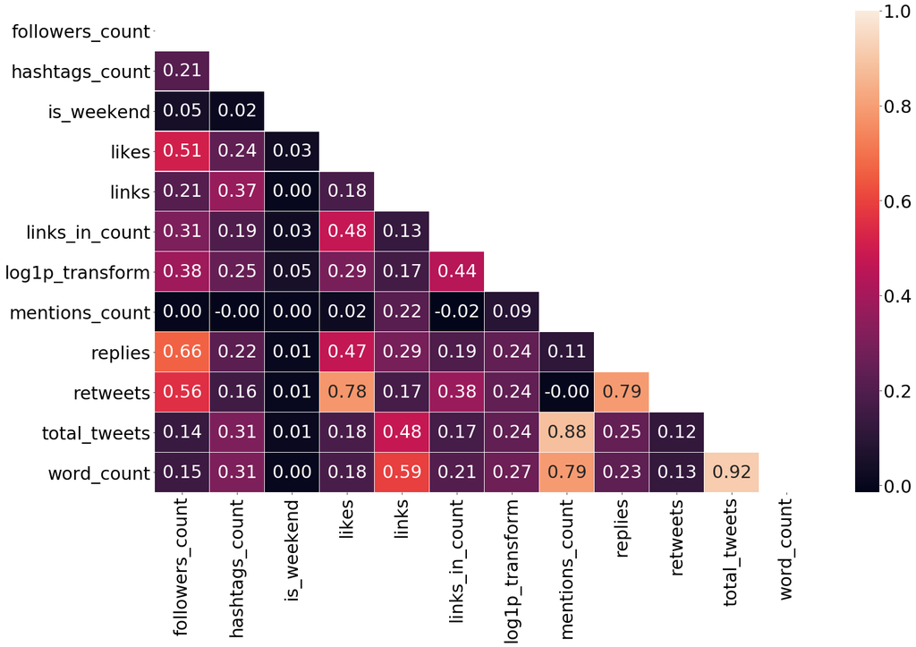

```python
plt.figure(figsize=(25,15))
sns.heatmap(corr,mask= mask, annot=True,linewidth=0.4, fmt=".2f")
```

# EDA

[figure not shown]

# Models

I choose to test out the below models:

- Random Forest Regresssion
- K-nn Regression
- Extra Tree Regression

Other regression models (Ridge and Linear) were performing badly (likely due to the nature of the relation between target and features)

# Models

[figure not shown]

| Metric\Model | Extra trees | K-nn | Random Forest Regressor |
| --- | --- | --- | --- |
| R2 | 0.94 | 0.85 | 0.94 |
| MAE | 5793 | 8525 | 6443 |

## Deeper Dive into Random Forest Regressor + Extra trees

[figure not shown]

## Deeper Dive into Random Forest Regressor + Extra trees

[figure not shown]

| Metric\Model | Extra trees | Random Forest Regressor |
| --- | --- | --- |
| R2 Adjusted | 0.96 | 0.95 |
| MAE | 5291 | 5866 |

### After Various comparison we will select the Extra Tree because:

- Faster than the Random Forest
- Extra tree has better scores (R2 - MAE)
- Cross validation scores are more consistent with Extra Trees

[figure not shown]

# Evaluating the Extra Trees Model

##### Interpreting the adjusted r2 :

Adjusted r2 takes into consideration how many independent variables are there in our model and sees how it's accuratly explaining the variability to our dependent variable. accuracy of the fit 96%.

# Feature importance:

[figure not shown]

- links_in_count: this gives an indication of how wide spread the site is
- followers_count: this will relate to how active this company is on twitter
- Shopping: as we saw earlier in the box plot the shopping category was one of height in terms of traffic so it makes absolute sense for it's importance

# What's Next?

#### Improvements:

- Feed model with variety of dates from different years to teach the model how traffic changes based on different quarters and months
- Evolve the model to include mobile app traffic
- Do some text processing to the gathered tweets and maybe find a pattern of words that would increase a site's traffic

# Thank you

[figure not shown]